# Data Science for Dummies

a guide written by Shilpa Roy and Amei Mbah

## Data Science: The Numbers Never Lie

With all of the talk about Big Data, it can be easy to dismiss data science and data analytics and choose to solve problems, particularly decision-making problems, using the “old” fashioned way (that is, using human intuition). The issue with diagnosing and problem-solving under such a strategy is that it is vulnerable to the biases and errors characteristic to humans.

For instance, have you ever had a time when your work and efforts were ignored and mountains of praise were heaped onto someone who probably did not deserve it? The matter of who deserves a promotion using no data is decided on the fly based on a subjective analysis of who “does the most work.” Numbers, on the other hand, never lie and are able to offer a degree of objectivity to such processes.

What data science seeks to do is to minimize unneeded subjectivity and ambiguity. While subjective decisions can always be contested, the unbiased nature of data lends problem-solving using data science legitimacy and respect.

However, although data in itself is unbiased and objective, the way data is *obtained, cleaned, analyzed, modeled, and presented* can lend itself to bias. If you think data analysis is the problem-solving tool you want to employ, you have to do these steps right. That isn’t just a subjective observation of ours, we’ll show you each of these steps in action and the necessity of getting them perfect!

## The Problem

The first step is to define a problem that needs solving. In the theme of looking at promotions, suppose I’m a worker in San Francisco and I want to know how pay is being distributed in my city. [This data set](https://www.kaggle.com/san-francisco/sf-employee-compensation) (taken from Kaggle) shows individual salaries for about 213,000 San Francisco City employees. The attributes include fiscal year, job title, department, overtime paid, as well as other benefits that the employee received over the year.

**Key Point #1: We obtained data from a reputable, trustoworthy source. For the conclusions we draw from our data to be legitimate, the data needs to be legitimate. Look for well-documented, well-sourced datasets that address your problem.**

With 213,000 individual data points, this dataset is pretty monstrous. In order to make sure the data is useful to our purpose of noticing general trends in the data and making models to represent the data, we need to “clean” the data. In this case, I want fast results, and processing and building plots and models for so much data would be difficult. To counteract it, let’s sample 5% of the data (still ~10,000 datapoints). Let’s use the `sample_frac` command to do just this and the `head` command to see the first couple of entries.

```r
set.seed(1)
sample <- data %>%
  sample_frac(.05)
head(sample)
```

```
## # A tibble: 6 x 22
##   `Year Type`  Year `Organization G… `Organization G… `Department Cod…
##   <chr>       <dbl> <chr>            <chr>            <chr>
## 1 Fiscal       2016 04               Community Health DPH
## 2 Fiscal       2015 01               Public Protecti… POL
## 3 Fiscal       2016 06               General Adminis… ADM
## 4 Fiscal       2016 06               General Adminis… REG
## 5 Fiscal       2013 02               Public Works, T… WTR
## 6 Fiscal       2014 06               General Adminis… BOS
## # … with 17 more variables: Department <chr>, `Union Code` <chr>,
## #   Union <chr>, `Job Family Code` <chr>, `Job Family` <chr>, `Job
## #   Code` <chr>, Job <chr>, `Employee Identifier` <dbl>, Salaries <dbl>,
## #   Overtime <dbl>, `Other Salaries` <dbl>, `Total Salary` <dbl>,
## #   Retirement <dbl>, `Health/Dental` <dbl>, `Other Benefits` <dbl>,
## #   `Total Benefits` <dbl>, `Total Compensation` <dbl>
```

A quality of life change we can make is changing the names of the individual columns in favor of naming conventions that make data processing easier.

Another thing we can notice about our data is whether there is missing data. If our data is missing [**systematically**](https://towardsdatascience.com/how-to-handle-missing-data-8646b18db0d4) then that means there is an error in the way the data was obtained, indicating the reliability of the data is potentially compromised. If the data is missing [**at random**](https://towardsdatascience.com/how-to-handle-missing-data-8646b18db0d4), then we can choose to either impute the values (by replacing relevant values with their means, etc.) or by choosing to ignore them altogether.

**Key Point #2: We “cleaned” the data by taking a *random* sample of our data and since some of our data was missing at random, we decide to ignore those values in our computations.**

```r
sample <- sample %>%
  select(-`Year Type`) %>%
  rename(year = Year, orgCode = `Organization Group Code`, org = `Organization Group`, deptCode = `Department Code`, dept = Department, unionCode = `Union Code`, union = Union, jobFamCode = `Job Family Code`, jobFam = `Job Family`, jobCode = `Job Code`, job = Job, empId = `Employee Identifier`, baseSalary = Salaries, overtime = Overtime, otherSalary = `Other Salaries`, totalSalary = `Total Salary`, retirement = Retirement, health = `Health/Dental`, otherBenefits = `Other Benefits`, totalBenefits = `Total Benefits`, totalComp = `Total Compensation`) %>%
  mutate(orgCode = factor(orgCode), deptCode = factor(deptCode))

head(sample)
```

```
## # A tibble: 6 x 21
##    year orgCode org   deptCode dept  unionCode union jobFamCode jobFam
##   <dbl> <fct>   <chr> <fct>    <chr> <chr>     <chr> <chr>      <chr>
## 1  2016 04      Comm… DPH      DPH … 791       SEIU… 2300       Nursi…
## 2  2015 01      Publ… POL      POL … 911       Poli… Q000       Polic…
## 3  2016 06      Gene… ADM      ADM … 790       SEIU… 1300       Pub R…
## 4  2016 06      Gene… REG      REG … 790       SEIU… 1400       Cleri…
## 5  2013 02      Publ… WTR      WTR … 130       Auto… 7300       Journ…
## 6  2014 06      Gene… BOS      BOS … 022       Prof… 1800       Budge…
## # … with 12 more variables: jobCode <chr>, job <chr>, empId <dbl>,
## #   baseSalary <dbl>, overtime <dbl>, otherSalary <dbl>,
## #   totalSalary <dbl>, retirement <dbl>, health <dbl>,
## #   otherBenefits <dbl>, totalBenefits <dbl>, totalComp <dbl>
```

# Exploratory Data Analysis

Now that our data is prepped, it is time for us to get to the heart of the problem. Recall that our problem in this experiment is to notice general trends in how our city (San Francisco) pays the different departments it has under its employ. At a high level, we are guessing that a certain organization may be getting paid more over time or less over time. What we are hoping that the data showcases a level of association we can exploit by making a model that will tell us directly (as opposed to guessing) how these funds change over time.

Before we can make accurate models that will explain how funds are being allotted, it is necessary to visualize the data using plots. Visualizing the data with a clear focus on the problem we are trying to solve will make it easier to spot trends that will lead us to a model. For instance, since I want to see how organizations have been paid by San Francisco *over time*, I create a plot whose data is our random sample of employee compensations, whose mapping is between year and total compensation (with a delineation of organizations), and whose geometric representation is points.

**Key Point #3: It is necessary to visualize data to notice trends that will help us build a model. By using the *grammar of graphics*, which specifies data, mapping, and geometry, to create plots relating attributed of our data, we get closer to building a working model.**

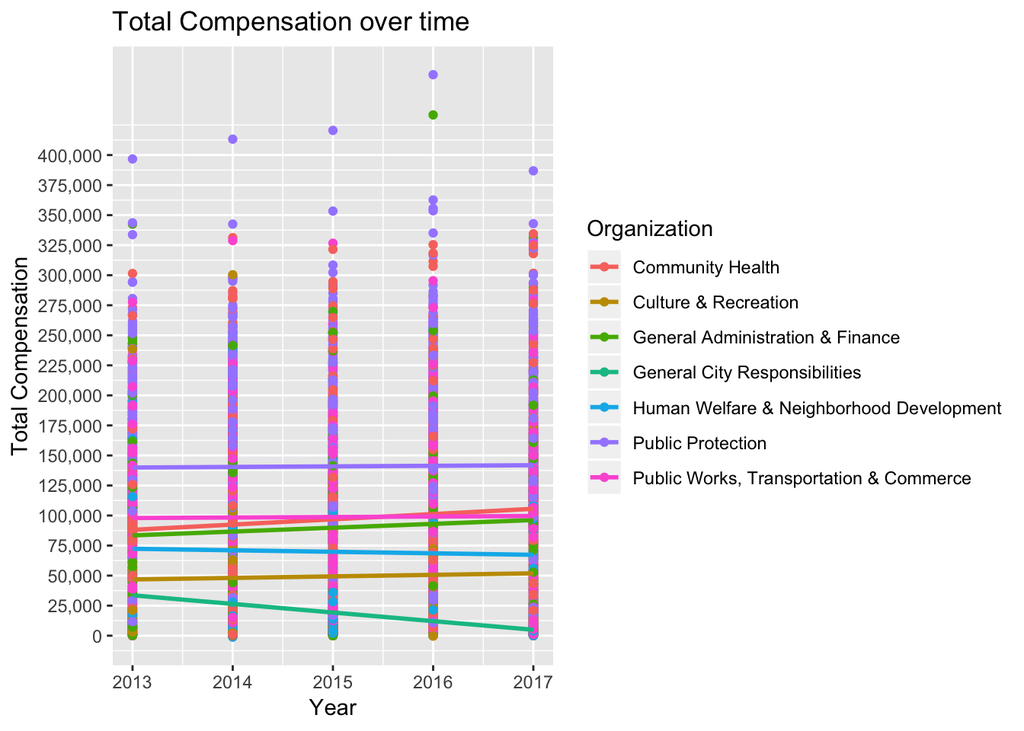

```r
sample %>%
  ggplot(mapping=aes(y = totalComp, x = year, color = org)) +
    geom_point(mapping=aes(color = org)) +
    labs(title = "Total Compensation over time", x = "Year", y = "Total Compensation", color = "Organization") +
    scale_y_continuous(labels = comma, breaks = round(seq(0, 400000, by = 25000),1)) +
    geom_smooth(method = lm, se = FALSE)
```

This first plot is incredibly chaotic and hard to decipher. Some organization’s trend lines seem to overlap with one another and the way the points are distributed makes it hard to see any general trends.

Before we dive into making this plot better, observe the following plot.

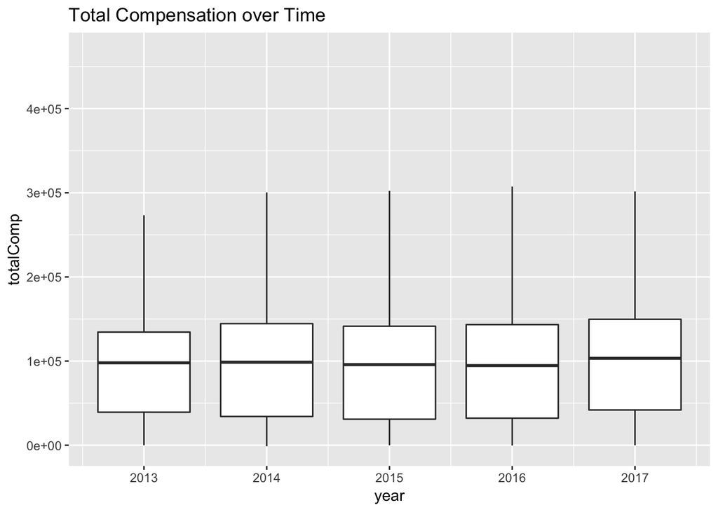

```r
  sample %>%
    ggplot(mapping=aes(x=year, y=totalComp, group = year)) + geom_boxplot(outlier.color = NA) + ggtitle("Total Compensation over Time")
```

The comparative boxplots above is the same data that we used in the initial plot. However, because we have chosen to represent it without conditioning, we see no trends based on organization. (Even if our initial scatterplot doesn’t seem to show a relation amongst organizations and pay over the years anyway, the reason why this is important is explained in Key Point #4 below).

**Key Point #4: The way you present data changes how the data is viewed and potentially the conclusions one will make from it. Use plots that are most descriptive and actually pertinent to the problem at hand in this case.**

For us, instead of using the boxplot, we use the other plot, because our problem is to look at how the city of San Francisco allocates money for different organizations/departments, so a good plot will be one that includes those attributes in some way.

Alright, now back to making that original plot better. In order to make our exploratory data analysis more impactful, we use something called [data conditioning](https://www.janacorp.com/blog/what-data-conditioning-and-cleaning), where we group our entities (the different people whose salaries we are examining) based on some attributes (characteristics of our entities, such as salary).

Here we decide to group based on organization and year. Why? This is because we want to notice general trends in the different organizations as time goes by. Since organizations are made up of hundreds of individual points, we want to group them all together, but we want to make sure we separate entities with different years! Thus, in a very logical way, we *condition* on organization and year. To get rid of the chaos caused by individual data points, we attempt to *summarize* the data by using the mean, because that gives us a gauge for the central, or typical, salary of an employee belonging to a certain organization at a certain time.

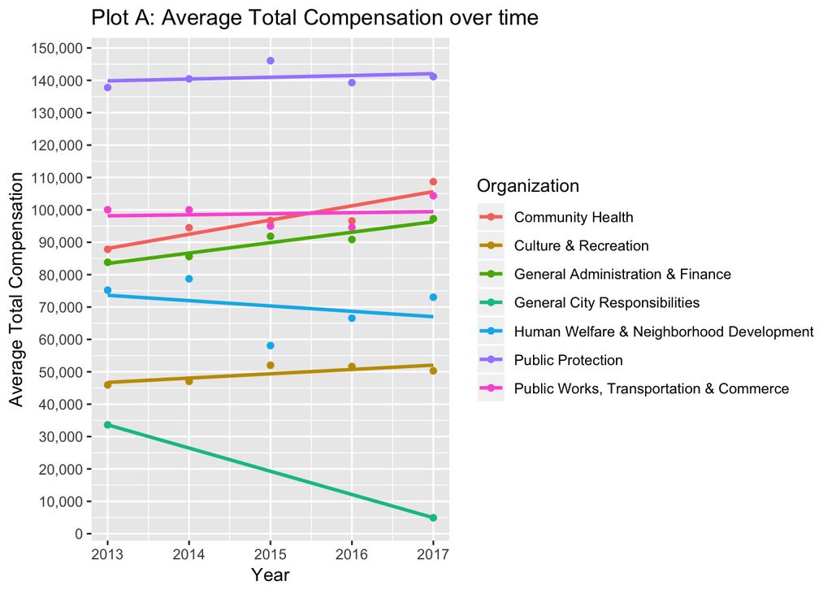

```r
sample %>%
  group_by(org, year) %>%
  summarize(total = mean(totalComp)) %>%
  ggplot(mapping=aes(y=total, x = year, color = org)) +
    geom_point(mapping=aes(color = org)) +
    labs(title="Plot A: Average Total Compensation over time", x = "Year", y = "Average Total Compensation", color = "Organization") +
    scale_y_continuous(labels = comma, breaks = round(seq(0, 300000, by = 10000),1)) +
    geom_smooth(method=lm, se = F)
```

With this plot, it is easy to see the different trends that San Francisco employee compensations have been taking. There does seem to be a slight correlation between payroll over the years based on the different organizations.

There are many different departments within each of these organizations. How do I know the money being allotted to each department individually also doesn’t change? As we discussed before, the way we look at this at a high level (once again, with the ultimate end goal of creating an accurate model) is through data visualization.

We can begin this processs by creating a faceted graph that shows the total compensation for all the organizations over time, using the average compensation of each department as our data points. This gives a general idea of the trends in the data. To see things at an even more granular level, we can do some in depth analysis on a single organizations and its departments.

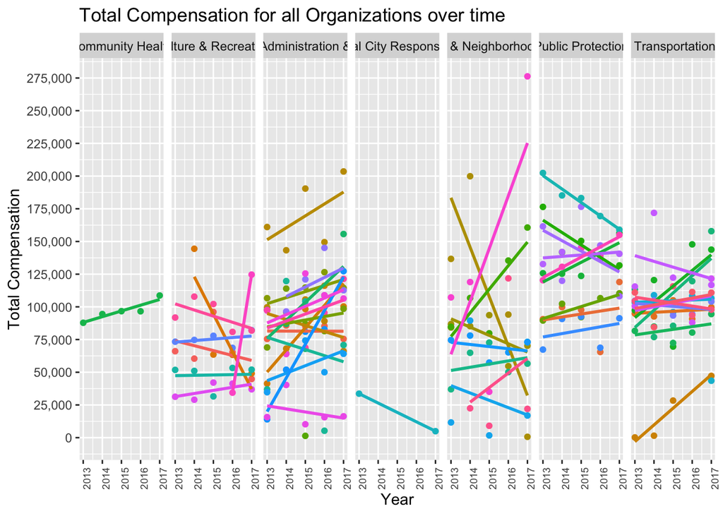

```r
sample %>%
  group_by(year, org, dept) %>%
  summarize(total = mean(totalComp)) %>%
  ggplot(mapping = aes(x = year, y = total, color = dept)) +
    facet_grid(cols = vars(org)) +
    geom_point() +
    geom_smooth(method = lm, se = FALSE) +
    scale_y_continuous(labels = comma, breaks = round(seq(0, 300000, by = 25000),1)) +
    labs(title = "Total Compensation for all Organizations over time", x = "Year", y = "Total Compensation", color = "Department") +
    theme(legend.position="none")+
  theme(axis.text.x = element_text(angle = 90, hjust = 1, size = 7))
```

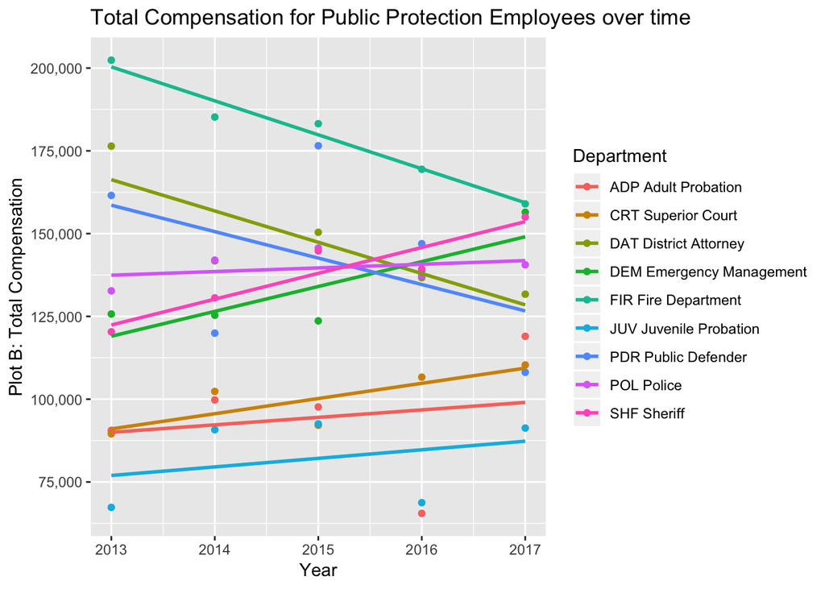

```r
first <- filter(sample, orgCode == "01")

first %>%
  group_by(dept, year) %>%
  summarize(total = mean(totalComp)) %>%
  ggplot(mapping = aes(x = year, y = total, color = dept)) +
    geom_point() +
    geom_smooth(method = lm, se = FALSE) +
    scale_y_continuous(labels = comma, breaks = round(seq(0, 300000, by = 25000),1)) +
    labs(title = "Total Compensation for Public Protection Employees over time", x = "Year", y = "Plot B: Total Compensation", color = "Department")
```

Just like we suspected, although the public protection unit’s salary has stayed constant, many departments within the organization are (potentially) being underfunded.

## Model Making

Although we have a hunch that some departments are being underfunded, we don’t really have any real evidence other than our observations with a naked eye. Since the whole point of data analysis is to eliminate these type of subjective observations, we need to be sure our hunch is correct.

**Key Point #5: Every assumption we make about the data absolutely needs to be backed by evidence if the integrity of our model is to be maintained, as does every piece of analysis. An example is to use hypothesis testing methods as evidence.**

First, let’s see whether our assumption that the public protection department is getting increased funding over time is correct.

```r
first_lm <- lm(totalComp ~ year, first)
tidy(first_lm)
```

```
## # A tibble: 2 x 5
##   term        estimate std.error statistic p.value
##   <chr>          <dbl>     <dbl>     <dbl>   <dbl>
## 1 (Intercept) -830137.  2332018.    -0.356   0.722
## 2 year            482.     1157.     0.416   0.677
```

From the third plot, department DO seem to have an impact on total compensation, so let’s test for those.

```r
lm_dept <- lm(totalComp~dept, first)
tidy(lm_dept)
```

```
## # A tibble: 9 x 5
##   term                         estimate std.error statistic  p.value
##   <chr>                           <dbl>     <dbl>     <dbl>    <dbl>
## 1 (Intercept)                    99138.    10603.     9.35  2.22e-20
## 2 deptCRT Superior Court          1467.    12006.     0.122 9.03e- 1
## 3 deptDAT District Attorney      44853.    12915.     3.47  5.26e- 4
## 4 deptDEM Emergency Management   34448.    13459.     2.56  1.06e- 2
## 5 deptFIR Fire Department        78043.    11134.     7.01  3.23e-12
## 6 deptJUV Juvenile Probation    -17751.    12892.    -1.38  1.69e- 1
## 7 deptPDR Public Defender        40499.    14226.     2.85  4.46e- 3
## 8 deptPOL Police                 40608.    10879.     3.73  1.94e- 4
## 9 deptSHF Sheriff                39756.    11403.     3.49  5.00e- 4
```

At an $\alpha$ level of 0.05, almost all departments have p-values much much less than 0.05 with the expection of the Superior Court and Juveniile Probation.

Now we can create a model. This tutorial will discuss how to create and interpret linear regression models in depth, but be cognizant should know that there are plenty of other models, including polynomial regression, etc. Use what you think is best for the data represented, and if you obtain evidence through data analysis that the model is wrong, (which we will discuss soon), then you can either change the type of model you employ or change what types of data you are hoping to explain with your model.

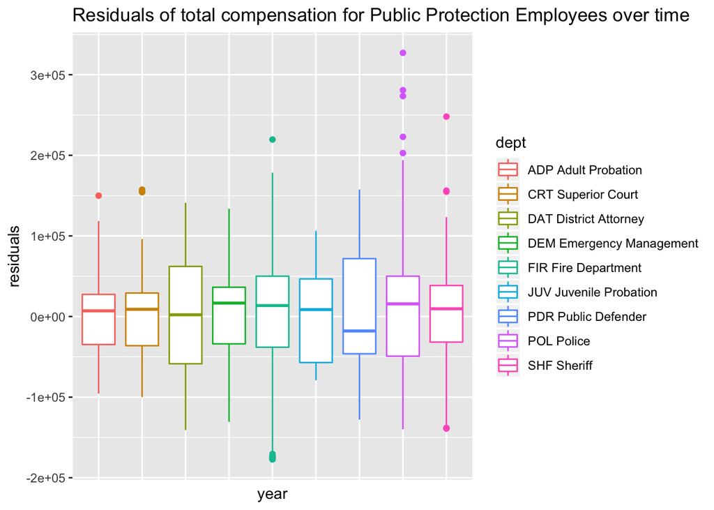

```r
lm_aug <- augment(lm_dept)

lm_aug %>%
  ggplot(aes(x=factor(dept), y=.resid, color = dept)) +
    geom_boxplot() +
    labs(title="Residuals of total compensation for Public Protection Employees over time",
         x = "year",
         y = "residuals") +  theme(axis.text.x=element_blank(), axis.ticks.x=element_blank())
```

**Key Point #6: Making a model is not enough. You have to evalaute the linear regression model for constant variance, and residuals centered around 0.**

This indicates we should either change our data or change our model. Let’s try changing our data. We know that department seems to indicate total compensation, but back in Plot B, we saw that department compensation actually seemed to differ based on year. Let’s add year back in and see what happens. Furthermore, your job within a department (supervisor vs intern) will also influence your compensation. Adding these additional factors in, we get the following residual plot.

```r
first_lm2 <- lm(totalComp ~ year + dept + job, first)
tidy(first_lm2)
```

```
## # A tibble: 200 x 5
##    term                          estimate std.error statistic p.value
##    <chr>                            <dbl>     <dbl>     <dbl>   <dbl>
##  1 (Intercept)                  -4901104.  1813474.    -2.70  0.00694
##  2 year                             2476.      900.     2.75  0.00600
##  3 deptCRT Superior Court         -67701.    59509.    -1.14  0.255
##  4 deptDAT District Attorney       48111.    25230.     1.91  0.0567
##  5 deptDEM Emergency Management    25186.    23066.     1.09  0.275
##  6 deptFIR Fire Department         41137.    28890.     1.42  0.155
##  7 deptJUV Juvenile Probation      11615.    14826.     0.783 0.434
##  8 deptPDR Public Defender         64935.    24936.     2.60  0.00928
##  9 deptPOL Police                  38167.    19175.     1.99  0.0467
## 10 deptSHF Sheriff                 42751.    25814.     1.66  0.0979
## # … with 190 more rows
```

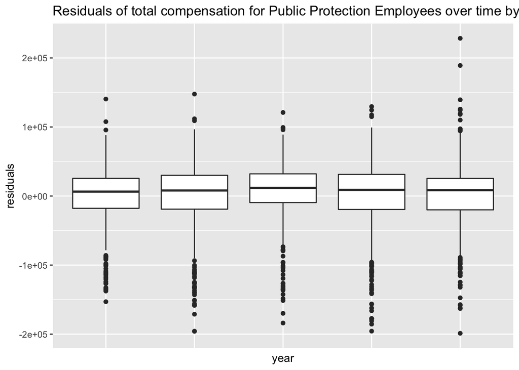

```r
first_aug2 <- augment(first_lm2)

first_aug2 %>%
  ggplot(aes(x=factor(year), y=.resid)) +
    geom_boxplot() +
    labs(title="Residuals of total compensation for Public Protection Employees over time by department",
         x = "year",
         y = "residuals") + theme(axis.text.x=element_blank(), axis.ticks.x=element_blank())
```

This plot showcases that our residuals are not centered around 0 (given that some residuals are in the 1000s) but their variability does seem to be nearly constant, indicating that our constant variance assumption is met.

Other than a residual plot, how do we know at a high level that one model is superior to another?

**Key Point #7: Use testing methods to get quanitifiable evidence that one model is better than another. For linear regression models, the anova function, which uses the F test, is a common way of achieving this**

```r
  anova(lm_dept, first_lm2)
```

```
## Analysis of Variance Table
##
## Model 1: totalComp ~ dept
## Model 2: totalComp ~ year + dept + job
##   Res.Df        RSS  Df  Sum of Sq      F    Pr(>F)
## 1   2048 1.0131e+13
## 2   1857 5.5231e+12 191 4.6084e+12 8.1123 < 2.2e-16 ***
## ---
## Signif. codes:  0 '***' 0.001 '**' 0.01 '*' 0.05 '.' 0.1 ' ' 1
```

Take a look at the Pr(>F) column. The fact that this probability is so miniscule indicates that we can reject the null that our two models are the same and conclude that the second model is superior to the first.

Now let’s try to generalize our findings to the whole sample as opposed to just samples from the very first organization.

```r
sample_lm <- lm(totalComp ~ year+dept+job, sample)
tidy(sample_lm)
```

```
## # A tibble: 866 x 5
##    term                            estimate std.error statistic     p.value
##    <chr>                              <dbl>     <dbl>     <dbl>       <dbl>
##  1 (Intercept)                    -3696478.   666627.   -5.55       3.02e-8
##  2 year                               1868.      331.    5.65       1.69e-8
##  3 deptADM Gen Svcs Agency-City …    -3658.    13501.   -0.271      7.86e-1
##  4 deptADP Adult Probation          -18290.    16651.   -1.10       2.72e-1
##  5 deptAIR Airport Commission         4108.    13246.    0.310      7.56e-1
##  6 deptART Arts Commission            1610.    22726.    0.0708     9.44e-1
##  7 deptASR Assessor / Recorder      -16966.    19025.   -0.892      3.73e-1
##  8 deptBOA Board Of Appeals - PAB     -747.    25423.   -0.0294     9.77e-1
##  9 deptBOS Board Of Supervisors       8184.    17649.    0.464      6.43e-1
## 10 deptCAT City Attorney             10683.    16133.    0.662      5.08e-1
## # … with 856 more rows
```

```r
summary(sample_lm)$r.squared
```

```
## [1] 0.6052675
```

```r
sample_aug <- augment(sample_lm)
```

These results indicate that the year is actually statisitcally significant in this model. Although not all the individual departments are statistically significant, the model returned an $R^{2}$ value of .6. **The R squared value tells us what proportion of the variance in the data is explained by our model** In theory, we want 100% of the variance to be explained by our model. In practice, values above 0.5 are impressive and indicates our model seems to be a good fit for the data.

Using our linear regression model, we can see that as time goes on, the average employee’s compensation increases by approximately $1,800. We can use our intuition to either attribute this to inflation, or to increased funding for raises. Further, depending on the department, the estimates showcase that if you keep everything else constant, being in the Board of Supervisors, for instance, will increase your salary by about $8000 more than the default value!

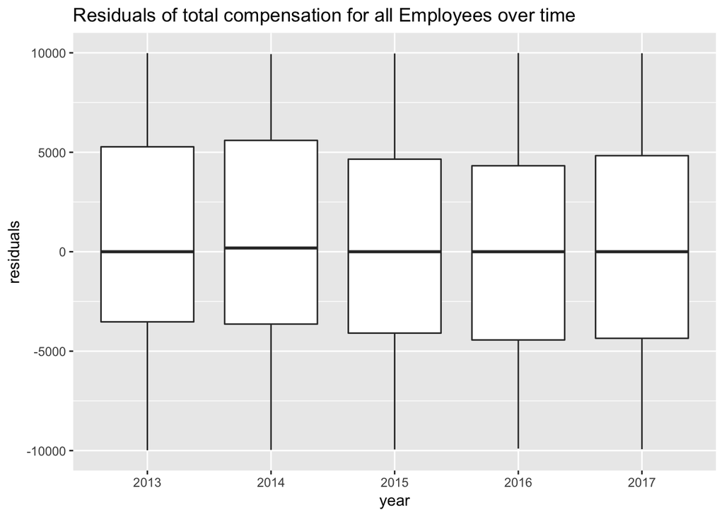

```r
sample_aug %>%
  ggplot(aes(x=factor(year), y=.resid)) +
    geom_boxplot(outlier.shape=NA) + scale_y_continuous(limit = c(-10000, 10000)) +
    labs(title="Residuals of total compensation for all Employees over time",
         x = "year",
         y = "residuals")
```

This residual plot is centered around 0 and the boxplots are nearly identical, indicating that our model adequately predicts total compensation given year, department and job. Great! Presenting these findings via our scatterplots to indicate how department impacts total compensation shows us how we can use our model to explain how different departments are valued by San Francisco.

## Drawing Conclusions

**Key Point #8: After you have evaluated your model and are sure it is adequate for the problem you are trying to solve, you are ready to make conclusions.**

Some sample conclusions I can now make (and be confident in their statistical significance) is a ranking of departments by their total compensation, among other benefits. I can also cross reference this ordering with the estimates I glean from my model. You’ve followed us this far! Test yourself by presenting the data in a meaningful way and keep track of which departments you might want to work for if you ever find yourself employed by the government of San Francisco!

```r
sample %>%
    group_by(org) %>%
    summarise(avg = mean(totalComp)) %>%
    arrange(desc(avg)) %>%
    rename("Total Compensation by Organization" = avg)
```

```
## # A tibble: 7 x 2
##   org                                    `Total Compensation by Organizati…
##   <chr>                                                               <dbl>
## 1 Public Protection                                                 140959.
## 2 Public Works, Transportation & Commer…                             98807.
## 3 Community Health                                                   97092.
## 4 General Administration & Finance                                   89993.
## 5 Human Welfare & Neighborhood Developm…                             69636.
## 6 Culture & Recreation                                               49506.
## 7 General City Responsibilities                                      27245.
```

```r
sample %>%
    group_by(dept) %>%
    summarise(avg = mean(totalComp)) %>%
    arrange(desc(avg)) %>%
    rename("Total Compensation by Department" = avg)
```

```
## # A tibble: 55 x 2
##    dept                           `Total Compensation by Department`
##    <chr>                                                       <dbl>
##  1 FIR Fire Department                                       177181.
##  2 CAT City Attorney                                         169329.
##  3 DAT District Attorney                                     143991.
##  4 POL Police                                                139746.
##  5 PDR Public Defender                                       139637.
##  6 SHF Sheriff                                               138894.
##  7 DEM Emergency Management                                  133586.
##  8 PRT Port                                                  124835.
##  9 MYR Mayor                                                 120494.
## 10 CFC Children & Families Commsn                            113602.
## # … with 45 more rows
```

```r
sample %>%
    group_by(dept) %>%
    summarise(avg = mean(baseSalary)) %>%
    arrange(desc(avg)) %>%
    rename("Base Salary by Department" = avg)
```

```
## # A tibble: 55 x 2
##    dept                           `Base Salary by Department`
##    <chr>                                                <dbl>
##  1 CAT City Attorney                                  122812.
##  2 DAT District Attorney                              103717.
##  3 FIR Fire Department                                101426.
##  4 PDR Public Defender                                 99857.
##  5 POL Police                                          89672.
##  6 PRT Port                                            88333.
##  7 MYR Mayor                                           83611.
##  8 SHF Sheriff                                         82433.
##  9 DEM Emergency Management                            80844.
## 10 CFC Children & Families Commsn                      80380.
## # … with 45 more rows
```

```r
sample %>%
    group_by(dept) %>%
    summarise(avg = mean(overtime)) %>%
    arrange(desc(avg)) %>%
    rename("Overtime by Department" = avg)
```

```
## # A tibble: 55 x 2
##    dept                           `Overtime by Department`
##    <chr>                                             <dbl>
##  1 FIR Fire Department                              25484.
##  2 SHF Sheriff                                      12747.
##  3 DEM Emergency Management                         10837.
##  4 POL Police                                       10266.
##  5 MTA Municipal Transprtn Agncy                     9501.
##  6 DT GSA - Technology                               4746.
##  7 HHP Hetch Hetchy Water & Power                    4060.
##  8 JUV Juvenile Probation                            4047.
##  9 WTR Water Enterprise                              4046.
## 10 FAM Fine Arts Museum                              3561.
## # … with 45 more rows
```

```r
sample %>%
    group_by(dept) %>%
    summarise(avg = mean(health)) %>%
    arrange(desc(avg)) %>%
    rename("Health & Dental Benefits by Department" = avg)
```

```
## # A tibble: 55 x 2
##    dept                           `Health & Dental Benefits by Department`
##    <chr>                                                             <dbl>
##  1 FIR Fire Department                                              12870.
##  2 CAT City Attorney                                                11316.
##  3 CSS Child Support Services                                       11306.
##  4 PDR Public Defender                                              11147.
##  5 SHF Sheriff                                                      11111.
##  6 PRT Port                                                         10706.
##  7 MYR Mayor                                                        10525.
##  8 CRT Superior Court                                               10444.
##  9 DEM Emergency Management                                         10405.
## 10 CFC Children & Families Commsn                                   10276.
## # … with 45 more rows
```

```r
sample %>%
    group_by(dept) %>%
    summarise(avg = mean(retirement)) %>%
    arrange(desc(avg)) %>%
    rename("Retirement Benefits by Department" = avg)
```

```
## # A tibble: 55 x 2
##    dept                           `Retirement Benefits by Department`
##    <chr>                                                        <dbl>
##  1 CAT City Attorney                                           24079.
##  2 FIR Fire Department                                         21119.
##  3 DAT District Attorney                                       20369.
##  4 SHF Sheriff                                                 20336.
##  5 PDR Public Defender                                         19422.
##  6 POL Police                                                  17306.
##  7 PRT Port                                                    16939.
##  8 DEM Emergency Management                                    16572.
##  9 MYR Mayor                                                   16179.
## 10 ECN Economic & Wrkfrce Dvlpmnt                              15326.
## # … with 45 more rows
```

```r
sample %>%
    group_by(dept) %>%
    summarise(avg = mean(totalBenefits)) %>%
    arrange(desc(avg)) %>%
    rename("Total Benefits by Department" = avg)
```

```
## # A tibble: 55 x 2
##    dept                           `Total Benefits by Department`
##    <chr>                                                   <dbl>
##  1 CAT City Attorney                                      44000.
##  2 PDR Public Defender                                    37943.
##  3 DAT District Attorney                                  37762.
##  4 FIR Fire Department                                    36666.
##  5 MYR Mayor                                              36357.
##  6 DEM Emergency Management                               35130.
##  7 PRT Port                                               35078.
##  8 SHF Sheriff                                            34044.
##  9 CFC Children & Families Commsn                         33223.
## 10 ECN Economic & Wrkfrce Dvlpmnt                         32955.
## # … with 45 more rows
```

## Wrap-up

**Key Point #9: The conclusions made using data science are 1) easily reproducible given the code for execution, 2) easily verifiable, and 3) statistically sound Fulfilling these three criteria not only gives your conclusions legitimacy, but will immensely aid anyone who wishes to continue research from where YOU left off.**